# CellANOVA Integration Pipeline

***Created on 04/24/2023***

***@author: jane***

In this notebook, we will provide a step-by-step illustration on how to run CellANOVA integration. For this tutorial, we will be using pancreas data from a type 1 diabetes by [***Maria Fasolino et al. (2022)***](https://www.nature.com/articles/s42255-022-00531-x). The data can be downloaded from [here](https://cellxgene.cziscience.com/collections/51544e44-293b-4c2b-8c26-560678423380). We have subsampled 20,000 cells for illustration purposes.

Let's start from loading required packages. We import `cellanova` package as `cnova`, which include two key modules:

- `model`: include important functions to fit the CellANOVA model and perform integration;
- `utils`: include helper functions to perform downstream analysis.

```python
import anndata as ad
import scanpy as sc
import gc
import sys
import cellanova as cnova
import numpy as np
import pandas as pd
import matplotlib.pyplot as plt
import seaborn as sea

sc.settings.verbosity = 0
sc.settings.set_figure_params(dpi=80)
pd.set_option('display.max_columns', None)
seed = 10
np.random.seed(seed)
```

## 1. Load data

The dataset is stored in AnnData format, using Python package `anndata`. After filtering cell outliers based on minimum number of genes expressed and filtering genes that expressed in too few cellls, the final dataset include 19812 cells and 20852 genes. This filtering step is optional, based on practical purposes and data quality. Other quality control steps should also be performed before applying CellANOVA integration.

In this study, pancreatic islet cells from 11 healthy control individuals, 5 individuals with T1D, and 8 individuals with no clinical presentation of T1D but positive for beta-cell auto-antibodies (AAB+) were sequenced. The metadata provided by the original study [***Maria Fasolino et al. (2022)***](https://www.nature.com/articles/s42255-022-00531-x) is shown as follows.

We will use the following three columns in the metadata:

- `'celltype'` : cell type
- `'dataidx'` : sample/individual id
- `'PseudoState'` : condition (T1D, AAB or Control)

```python
adata = sc.read_h5ad('t1d_example.h5ad')
sc.pp.filter_cells(adata, min_genes=300)
sc.pp.filter_genes(adata, min_cells=10)
print(adata.shape)
adata.obs
```

```
(19812, 20852)
```

|  | dataidx | celltype | disease_state | celltype_orig | donor_id | disease | assay | sex | ethnicity | development_stage | PseudoState | n_genes |
| --- | --- | --- | --- | --- | --- | --- | --- | --- | --- | --- | --- | --- |
| ACCAACATCCTTCACG-19 | HPAP050 | beta_minor | AAB | type B pancreatic cell | HPAP050 | normal | 10x 3' v3 | female | Hispanic or Latin American | 21 | AAB | 2981 |
| CAGTAACCAATGTAAG-12 | HPAP019 | beta_minor | AAB | type B pancreatic cell | HPAP019 | normal | 10x 3' v2 | male | European | 22 | AAB | 1065 |
| CAGAGAGGTCTAGTGT-14 | HPAP029 | hybrid | AAB | native cell | HPAP029 | normal | 10x 3' v2 | male | European | 23 | AAB | 4182 |
| AAGACCTCACATGGGA-14 | HPAP029 | acinar | AAB | pancreatic acinar cell | HPAP029 | normal | 10x 3' v2 | male | European | 23 | AAB | 3445 |
| ATCGTAGAGCTGAGCA-9 | HPAP042 | endothelial | Control | endothelial cell | HPAP042 | normal | 10x 3' v3 | male | European | 1 | Control | 1063 |
| ... | ... | ... | ... | ... | ... | ... | ... | ... | ... | ... | ... | ... |
| ACAGCTAGTTCCAACA-23 | HPAP028 | acinar | T1D | pancreatic acinar cell | HPAP028 | type 1 diabetes mellitus | 10x 3' v2 | male | European | 4 | T1D | 1072 |
| TCACATTAGTGGCGAT-8 | HPAP040 | alpha | Control | pancreatic A cell | HPAP040 | normal | 10x 3' v3 | male | European | 35 | Control | 2571 |
| TCTCTAAGTAAGTGGC-20 | HPAP020 | immune_stellates | T1D | native cell | HPAP020 | type 1 diabetes mellitus | 10x 3' v2 | male | European | 14 | T1D | 972 |
| CTACCCAGTACGCACC-12 | HPAP019 | stellates | AAB | pancreatic stellate cell | HPAP019 | normal | 10x 3' v2 | male | European | 22 | AAB | 2999 |
| ACTTCGCCAAGCCTGC-7 | HPAP039 | duct_major | Control | pancreatic ductal cell | HPAP039 | normal | 10x 3' v3 | female | European | 5 | Control | 2746 |

19812 rows × 12 columns

## 2. CellANOVA preprocess

Next, before integrating across samples, we will first need to use function `preprocess_data` in `cnova.model` module to transform raw counts expression into the standardized log1p-transformed data.

The inputs of this function `preprocess_data` are:

- `adata` : raw anndata, containing gene expression counts in `adata.X`.
- `integrate_key` : str, variable name indicating the smallest batch unit, which will be used for integration later. Should be a column name of adata.obs.
- `n_hvgs` (optional) : int, number of selected highly variable genes.
- `hvg_only` (optional) : boolean, whether or not return only highly variable genes or all genes.
- `copy_raw` (optional) : boolean, whether or not save a copy of raw counts.

The outputs of this function is a new anndata after preprocessing, in which we stored a new layer 'scale' and other highly variable gene information.

```python
adata_prep = cnova.model.preprocess_data(adata, integrate_key='dataidx')
adata_prep
```

```
AnnData object with n_obs × n_vars = 19812 × 3000
    obs: 'dataidx', 'celltype', 'disease_state', 'celltype_orig', 'donor_id', 'disease', 'assay', 'sex', 'ethnicity', 'development_stage', 'PseudoState', 'n_genes'
    var: 'highly_variable', 'means', 'dispersions', 'dispersions_norm', 'highly_variable_nbatches', 'highly_variable_intersection', 'mean', 'std'
    uns: 'log1p', 'hvg'
    layers: 'lognorm', 'scale'
```

## 3. Control pool construction

One innovation of CellANOVA is that we only used samples from control pool to estimate batch variation basis, and then project out batch effect for all samples and perform integration. Therefore we should first define control pool. One can find more principles and details for different control pool design in our paper. Here we will show the control pool construction for the type 1 diabetes study as an example.

Since the primary goal is to make comparisons between disease subgroups (i.e., T1D versus AAB+) and between diseased and healthy individuals, we will designate the 11 healthy individuals as the control-pool.

CellANOVA will require a Python dictionary as input in its later integration process. In this dictionary, each key is a control group, and the corresponding values are the integration units in this group. For example, here since 11 healthy individuals constitute a single control pool, so the dictionary will only have one key `'g1'`. And values in this group are the `'dataidx'` of all control samples.

```python
integrate_key = 'dataidx'
condition_key = 'PseudoState'
control_name = 'Control'
control_batches = list(set(adata_prep[adata_prep.obs[condition_key]==control_name,].obs[integrate_key]))
control_dict = {
    'g1': control_batches,
}
control_dict
```

```
{'g1': ['HPAP044',
  'HPAP035',
  'HPAP042',
  'HPAP039',
  'HPAP040',
  'HPAP047',
  'HPAP036',
  'HPAP026',
  'HPAP037',
  'HPAP022',
  'HPAP034']}
```

Suppose one has multiple control pools, then he/she can define a control dictionary like the following one. Here are three control groups `'g1'` , `'g2'` , `'g3'`, two of them have 3 samples, one has 4 samples. Values in each control group are the corresponding `'dataidx'` of control samples within each group. `'dataidx'` is the `integration_key` we used for preprocessing and later integration.

```
control_dict = {
    'g1': ['HPAP047', 'HPAP039', 'HPAP042'],
    'g2': ['HPAP044', 'HPAP034', 'HPAP040', 'HPAP036'],
    'g3': ['HPAP026', 'HPAP035', 'HPAP037'],
}
```

## 4. Calculate main effect

The first step of CellANOVA integration is to estimate cell state-encoding and main effects by regressing the original expression vectors on the cell state-encoding. It is achieved by the following function `cnova.model.calc_ME`.

The main inputs of this function are:

- `adata` : Preprocessed anndata object. This object should be the output of the function `cnova.model.preprocess_data`.
- `integrate_key` : str. Variable name indicating the smallest batch unit/sample, which will be used for integration. Should be a column name of adata.obs.
- `dim_ME` (optional) : int, dimension of main effects. Defualt is 70.
- `k_harmony` (optional) : int, number of principle components used in harmony integration. Defualt is 70.

The output is anndata object, in which we stored the following main information:

- `adata.obsm['Cmat']` : np.array, the estimated cell embedding.
- `adata.varm['Mmat']` : np.array, the estimated main effect matrix.

```python
adata_prep= cnova.model.calc_ME(adata_prep, integrate_key='dataidx')
adata_prep
```

```
2023-04-24 09:51:07,166 - harmonypy - INFO - Computing initial centroids with sklearn.KMeans...
2023-04-24 09:51:13,873 - harmonypy - INFO - sklearn.KMeans initialization complete.
2023-04-24 09:51:13,962 - harmonypy - INFO - Iteration 1 of 30
2023-04-24 09:51:18,804 - harmonypy - INFO - Iteration 2 of 30
2023-04-24 09:51:24,379 - harmonypy - INFO - Iteration 3 of 30
2023-04-24 09:51:30,176 - harmonypy - INFO - Iteration 4 of 30
2023-04-24 09:51:35,780 - harmonypy - INFO - Iteration 5 of 30
2023-04-24 09:51:40,575 - harmonypy - INFO - Iteration 6 of 30
2023-04-24 09:51:45,472 - harmonypy - INFO - Iteration 7 of 30
2023-04-24 09:51:48,450 - harmonypy - INFO - Iteration 8 of 30
2023-04-24 09:51:50,880 - harmonypy - INFO - Converged after 8 iterations
```

```
AnnData object with n_obs × n_vars = 19812 × 3000
    obs: 'dataidx', 'celltype', 'disease_state', 'celltype_orig', 'donor_id', 'disease', 'assay', 'sex', 'ethnicity', 'development_stage', 'PseudoState', 'n_genes'
    var: 'highly_variable', 'means', 'dispersions', 'dispersions_norm', 'highly_variable_nbatches', 'highly_variable_intersection', 'mean', 'std'
    uns: 'log1p', 'hvg'
    obsm: 'Cmat'
    varm: 'Mmat'
    layers: 'lognorm', 'scale', 'main_effect'
```

## 5. Calculate batch effect, perform batch correction

Next is wo estimate batch variation basis matrix with the control-pool samples that we contructed above. We will use function `cnova.model.calc_BE`. The main inputs of this function are:

- `adata` : anndata object. This object should be the output of the function `cnova.model.calc_ME`.
- `integrate_key` : str. Variable name indicating the smallest batch unit/sample, which will be used for integration. Should be a column name of adata.obs.
- `control_dict` : dict. A dictionary, in which each key is a control group, and the corresponding values are the integration units in this group.
- `var_cutoff` (optional) : float, between 0 and 1. Fraction of explained variance to determine the optimal value of k in truncated SVD.
- `k_max` (optional) : int. Max of singular values and vectors to compute.
- `verbose` (optional) : boolean. Whether to plot sigular values or not.
- `k_select` (optional) : int. Pre-determined number of singular values and vectors to compute.

The output is anndata object, in which we stored the following main information:

- `adata.varm['V_BE_basis']` : np.array, batch variation basis matrix.
- `adata.uns['S_BE_basis']` : np.array, singular values of batch basis.

```python
adata_prep = cnova.model.calc_BE(adata_prep,
                                 integrate_key='dataidx',
                                 control_dict=control_dict)
adata_prep
```

```
AnnData object with n_obs × n_vars = 19812 × 3000
    obs: 'dataidx', 'celltype', 'disease_state', 'celltype_orig', 'donor_id', 'disease', 'assay', 'sex', 'ethnicity', 'development_stage', 'PseudoState', 'n_genes'
    var: 'highly_variable', 'means', 'dispersions', 'dispersions_norm', 'highly_variable_nbatches', 'highly_variable_intersection', 'mean', 'std'
    uns: 'log1p', 'hvg', 'S_BE_basis'
    obsm: 'Cmat'
    varm: 'Mmat', 'V_BE_basis'
    layers: 'lognorm', 'scale', 'main_effect', 'corrected'
```

## 6. Calculate treatment effect, integrate all samples

The final step for CellANOVA is to use function `cnova.model.calc_TE` to compute treatment effect and perform integration. The main inputs of this function are:

- `adata` : anndata object. This object should be the output of the function `cnova.model.calc_BE`.
- `integrate_key` : str. Variable name indicating the smallest batch unit/sample, which will be used for integration. Should be a column name of adata.obs.
- `var_cutoff` (optional) : float, between 0 and 1. Fraction of explained variance to determine the optimal value of k in truncated SVD.
- `k_max` (optional) : int. Max of singular values and vectors to compute.
- `verbose` (optional) : boolean. Whether to plot sigular values or not.
- `k_select` (optional) : int. Pre-determined number of singular values and vectors to compute.

The output is anndata object, in which we stored the following main information:

- `adata.varm['W_TE_basis']` : np.array, treatment effect basis matrix.
- `adata.uns['S_TE_basis']` : np.array, singular values of treatment basis.
- `adata.layers['denoised']` : np.array, the integrated data.

```python
adata_prep = cnova.model.calc_TE(adata_prep, integrate_key='dataidx')
adata_prep
```

```
AnnData object with n_obs × n_vars = 19812 × 3000
    obs: 'dataidx', 'celltype', 'disease_state', 'celltype_orig', 'donor_id', 'disease', 'assay', 'sex', 'ethnicity', 'development_stage', 'PseudoState', 'n_genes'
    var: 'highly_variable', 'means', 'dispersions', 'dispersions_norm', 'highly_variable_nbatches', 'highly_variable_intersection', 'mean', 'std'
    uns: 'log1p', 'hvg', 'S_BE_basis', 'S_TE_basis'
    obsm: 'Cmat'
    varm: 'Mmat', 'V_BE_basis', 'W_TE_basis'
    layers: 'lognorm', 'scale', 'main_effect', 'corrected', 'trt_effect', 'denoised'
```

```python
adata_prep.write_h5ad('t1d_example_integrated.h5ad')
```

## 7. UMAP visualization

To eatract integrated data, one can use this command `adata_prep.layers['denoised']`. Here we create a new anndata storing the integrated results and plot UMAP, colored by batch('dataidx'), celltype, and condition ('PseudoState').

```python
integrated = ad.AnnData(adata_prep.layers['denoised'], dtype=np.float32)
integrated.obs = adata_prep.obs.copy()
integrated.var_names = adata_prep.var_names
sc.pp.neighbors(integrated, n_neighbors=15, n_pcs=30)
sc.tl.umap(integrated)
```

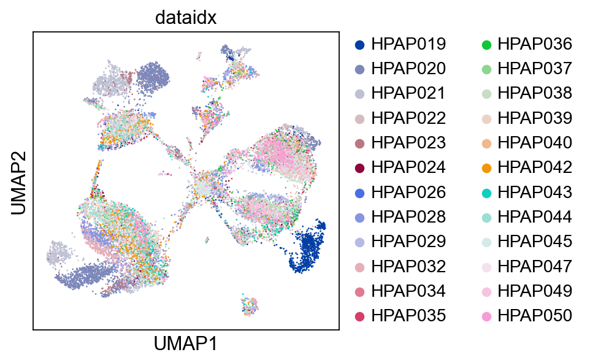

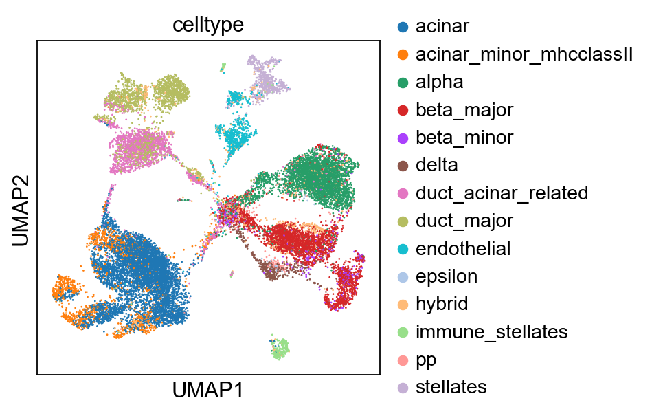

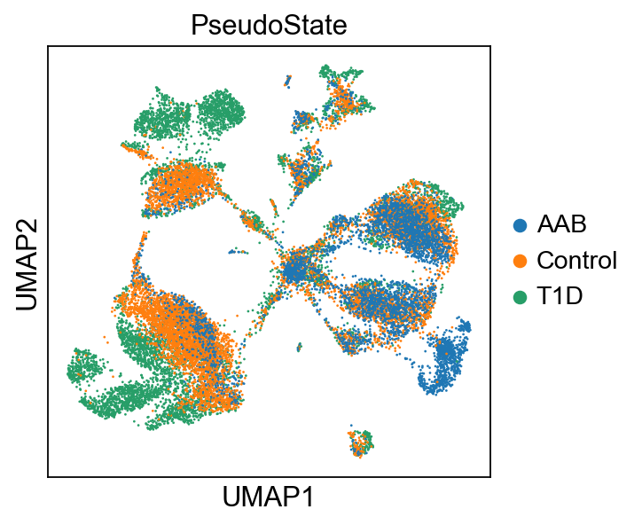

```python
sc.pl.umap(integrated, color=['dataidx'])
sc.pl.umap(integrated, color=['celltype'])
sc.pl.umap(integrated, color=['PseudoState'])
```

For other downstream analysis based on CellANOVA-integrated data, please refer to other notebooks that we provided.